# Ficha 1- Resolução

Diogo Silva

2025-09-30

## Exercício 1

A tabela lista o número de casos de SIDA (em milhares) em 25 grandes cidades dos Estados Unidos durante o ano de 1992.

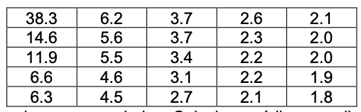

Construa o histograma para descrever os dados. Calcule a média, a mediana, a amplitude e o desvio padrão. Qual a proporção de cidades com mais de 10 000 casos de SIDA em 1992?

### Resolução

1º temos que importar os dados, i.e, criar um vetor com os valores da tabela. Também podia ser usado um dataframe para isto.

```
xValues = c(38.3,6.2,3.7,2.6,2.1,
            14.6,5.6,3.7,2.3,2.0,
            11.9,5.5,3.4,2.2,2.0,
            6.6,4.6,3.1,2.2,1.9,
            6.3,4.5,2.7,2.1,1.8)

xValues
```

```
 [1] 38.3  6.2  3.7  2.6  2.1 14.6  5.6  3.7  2.3  2.0 11.9
[12]  5.5  3.4  2.2  2.0  6.6  4.6  3.1  2.2  1.9  6.3  4.5
[23]  2.7  2.1  1.8
```

```
#mais fácil para importar dados
xValues = read.csv(file="ficheiros_ficha1_mais/sida_acb1.csv", sep=" ", dec=",")

sida_acb1 <- read_csv("ficheiros_ficha1_mais/sida_acb1.csv",
 locale = locale(decimal_mark = ","))
```

2º Criar o histograma com os valores do vetor xValues.

```
#Frequências Relativas
histograma = hist(xValues$X1,
     include.lowest = TRUE, right = TRUE, fuzz = 1e-7,
     density = NULL, angle = 45, col = "lightgray", border = NULL,
     main = paste("Número de Casos de Sida em 25 cidades"),
     ylim = NULL,
     xlab = "Casos de sida", ylab = "Frequência",
     axes = TRUE, plot = TRUE, labels = FALSE,
     nclass = NULL, warn.unused = TRUE,probability = TRUE)
```

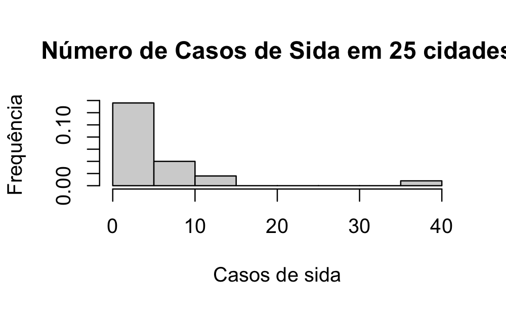

```
#Frequências absolutas
histograma1 = hist(xValues$X1,
     include.lowest = TRUE, right = TRUE, fuzz = 1e-7,
     density = NULL, angle = 45, col = "lightgray", border = NULL,
     main = paste("Número de Casos de Sida em 25 cidades"),
     ylim = NULL,
     xlab = "Casos de sida", ylab = "Frequência",
     axes = TRUE, plot = TRUE, labels = FALSE,
     nclass = NULL, warn.unused = TRUE)
```

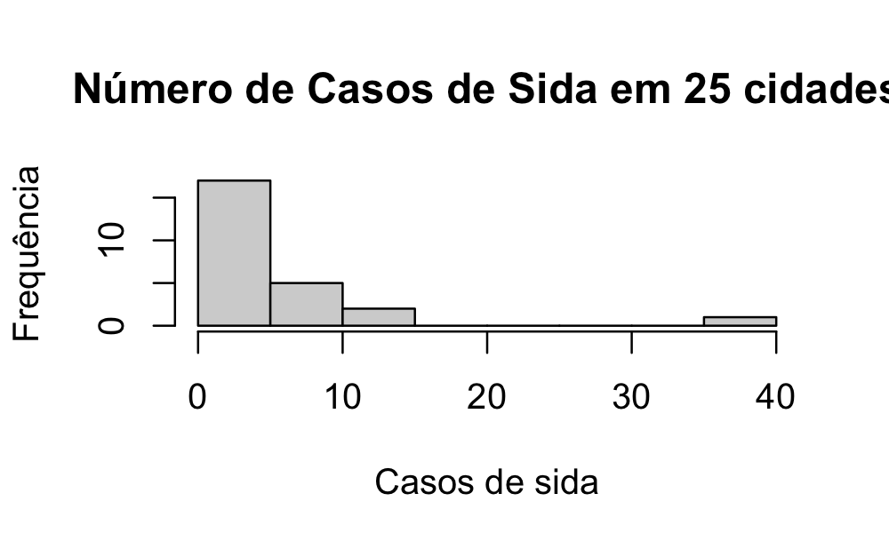

[output not shown]

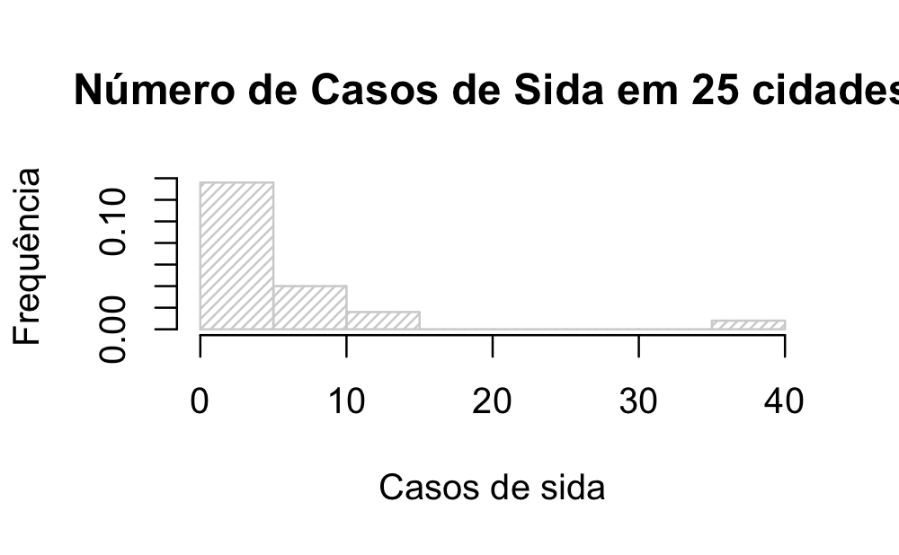

```
boxplot(xValues$X1, horizontal = T)
```

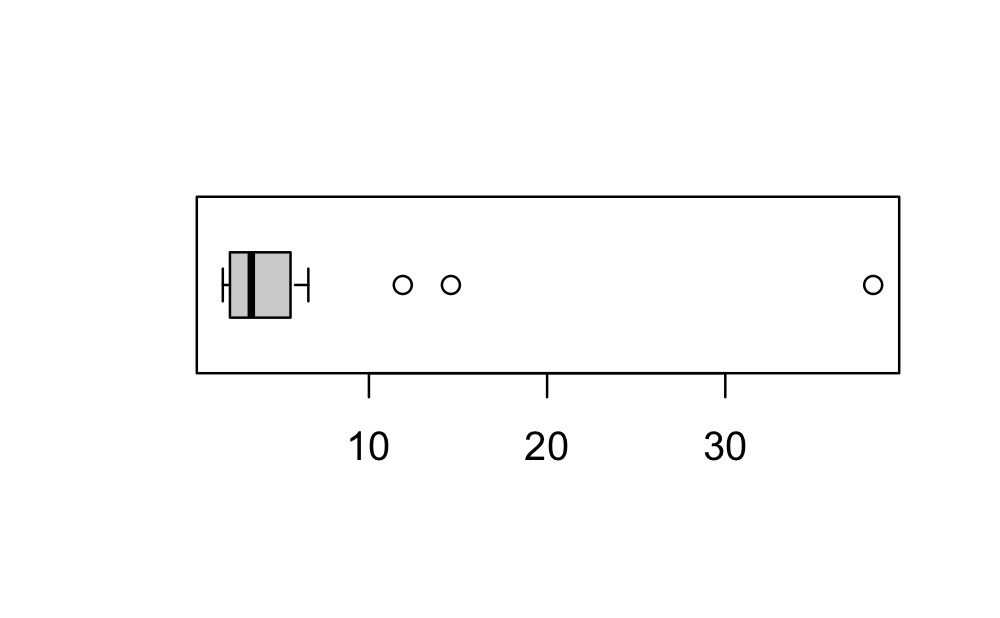

```
boxplot.stats(xValues$X1)
```

```
$stats
[1] 1.8 2.2 3.4 5.6 6.6

$n
[1] 25

$conf
[1] 2.3256 4.4744

$out
[1] 11.9 14.6 38.3
```

### Média

[output not shown]

### Mediana

[output not shown]

### Amplitude

Temos 2 vias para calcular a amplitude. Calculando o máximo e o mínimo e fazendo max-min. Ou utilizando o comando range()

[output not shown]

### Desvio padrão

[output not shown]

### Calcular proporção

Proporção = nº casosFavoraveis / nº casosTotais

Temos que calcular o nº de cidades com mais de 10000 casos logo:

[output not shown]

A seguir calculamos o nº total de cidades, neste caso 25:

[output not shown]

A proporção é dada pelo nº de cidades com mais de 10000 casos a dividir pelo total de cidades:

[output not shown]

[output not shown]

[output not shown]

[output not shown]

## Exercício 2

```
cidades = data.frame(
  Cidade = c("Tokyo","Seoul","Mexico City","New York","Bombay","Delhi",
             "Sao Paulo","Los Angeles","Shanghai","Osaka","Cairo","Calcutta",
             "Manila","Jakarta","Karachi","Canton","Dacca","Buenos Aires",
             "Moscow","Beijing","Rio de Janeiro","Tehran","London","Istanbul",
             "Lagos","Paris","Chicago","Shenzhen","Bangkok","Wuhan"),
  Pais = c("Japan","South Korea","Mexico","USA","India","India",
           "Brazil","USA","China","Japan","Egypt","India",
           "Philippines","Indonesia","Pakistan","China","Bangladesh","Argentina",
           "Russia","China","Brazil","Iran","Great Britain","Turkey",
           "Nigeria","France","USA","China","Thailand","China"),
  Pop = c(33.40,23.20,22.10,21.80,21.30,21.10,
          20.40,17.90,17.30,16.60,15.90,15.50,
          15.40,14.90,14.80,14.50,13.80,13.50,
          13.40,12.70,12.20,12.10,12.00,11.70,
          10.00,9.95,9.75,9.00,8.55,8.55)
)
```

[output not shown]

Para criar um gráfico de barras convém ordenar os valores… Para ordenar os valores tempos que “modificar” os valores da coluna pretendida

[output not shown]

Fazendo cidade$Cidade[populacaoSorted] -> estamos a aceder ao vetor com a ordem que definimos anteriormente

## Exercicio 3 .

Na tabela abaixo são apresentados os valores calóricos de 3 tipos de “hamburgers”:

```
tipoHamburguer = data.frame(vegetariano = c(168,77,185.1,183.7,181.4,183.1,181.9,175.4,172.3,170.9,
                  184.6,166.7,154.8,195.7,174.2),
  carne = c(145.5,158.3,132.7,163.3,171.7,166.3,172.2,157.8,177.7,170.9,
            131.1,161.8,162.9,182.1,134.7),
  frango = c(101.1,105,85.3,117.8,99.9,121,111.3,120.4,89.5,99.5,
             76.8,84.5,88.2,93.6,115.1))
```

Estatísticas descritivas simples

[output not shown]

Média das colunas ig

[output not shown]

Desvio Padrão por coluna

[output not shown]

[output not shown]

## Exercício 4

```
dadosBebes = read.csv(file="ficheiros_ficha1_mais/peso_bebes.csv")
```

```
sampleBebes = sample(dadosBebes$peso,15)
```

Média,Mediana, Moda (Valor que aparece + vezes), Amplitude e desvio padrão

[output not shown]

```
dadosBebesPlus10 = Map(function(x) x+10,dadosBebes$peso)
```

3. Considere a amostra recolhida. Multiplique cada valor por 2. O que acontece ao valor da média e do desvio padrão? ?? da amostra ou do dataset ?

## Exercício 5

```
c_inter_orb = read.csv(file="ficheiros_ficha1_mais/pombos.csv", sep=" ", dec=",")
c_inter_orb
```

| comp |
| --- |
| 12.2 |
| 12.9 |
| 11.8 |
| 11.9 |
| 11.6 |
| 11.1 |
| 12.3 |
| 12.2 |
| 11.8 |
| 11.8 |

[output cut: 30 more lines]

```
summary(c_inter_orb$comp)
```

```
   Min. 1st Qu.  Median    Mean 3rd Qu.
  10.20   10.97   11.60   11.48   11.90
   Max.
  13.30
```